# homework11

Vicvtor Aluko

May 10, 2017

```r
library(ggplot2)
```

## Exercise 1

For this task I used the filters to filter out the data for 3 counties; Tartu, Tallinn and Parnu. I used Microsoft Excel to complete the task. For each of the counties, I first filtered by the column for business type (Column C). SO based on the 7 Business Types, I used Sort to get the Business names with the highest values in the Number of Employees, Turnover, Emplyee Taxes and All Taxes columns. Also, because some columns contained null values, I had to filter out the null values and use only the available values in the numeric columns

Detailed breakdown of the results of the study are as follows:

### Äriühing

#### Harjumaa/Tallinn

In the Äriühing business type, All purpose stores Like Maxima, Rimi and Selver had the highest number of employees as indicated in the image below

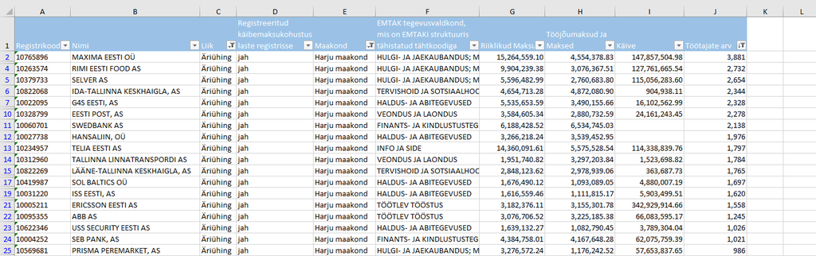

Tallinn Ariuhing Highest Employee Companies

Companies like Telia, Maxima, SEB Bank and G4S were also amoung the highest when I filtered by highest employee taxes

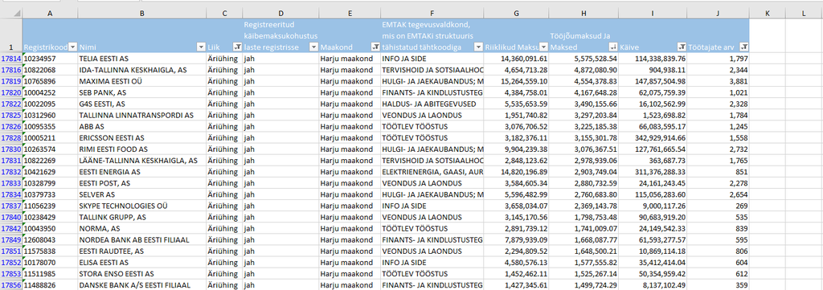

Tallinn Ariuhing Highest Employee Taxes Companies

While Ericsson Eesti and Eesti Energia were the companies with the highest turnovers.

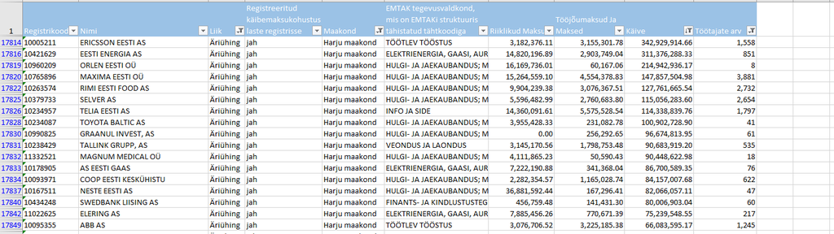

Tallinn Ariuhing Highest Turnover Companies

We can also see that Maxima, Rimi and Selver were among the top 10 highest turnover companies. Hence we can conclude that **Maxima Eesti**, **Rimi Eesti Food** and **Selver AS** are the largest companies in the **Äriühing** business type category

#### Tartu

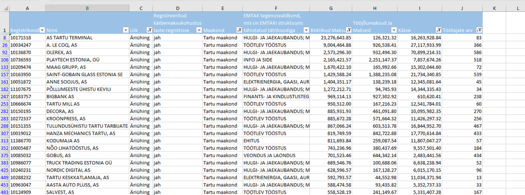

#### Parnu

In the Parnu county, the 2 consistently largest companies across all fieds are **WENDRE AS** and **SCANFIL OÜ**

[figure not shown]

### Eestis asuv rahvusvaheline organisatsioon

In this Business type, only 2 companies exist, 1 in Harjumaa and 1 in Tartu. Hence its difficult to make any inferences

### Valitsus- ja riigiasutus

#### Tartu

In Tartu county, **Tartu Ulikooli** was the largest company, in filters of number of employees, turnover and tax. **TARTU LINNAVALITSUS** was next.

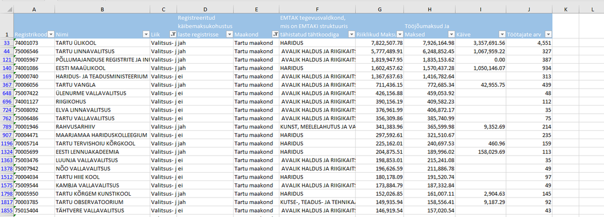

Tartu Valitsus Largest Companies

#### Parnu

In Parnu, the largest companies in this business type are **PÄRNU LINNAVALITSUS** and **PÄRNUMAA KUTSEHARIDUSKESKUS**. They had the highest values across all 4 possible filters

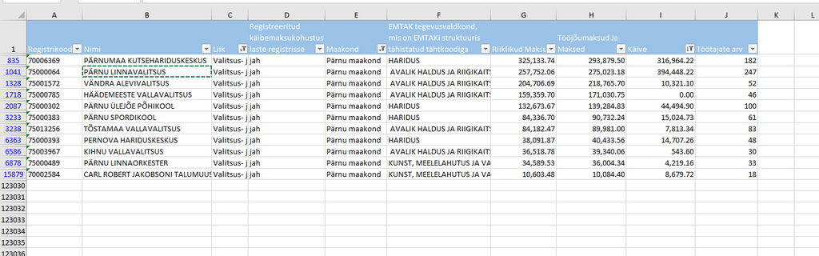

Parnu Valitsus Largest Companies

#### Harjumaa/Tallinn

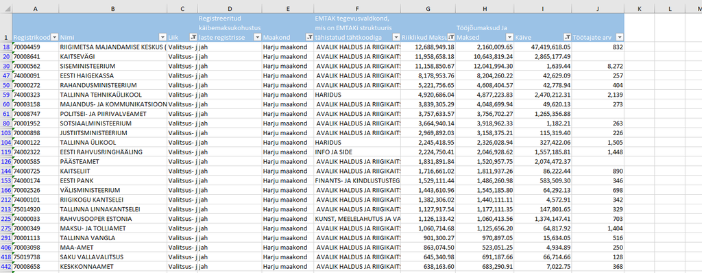

## Exercise 2

For this exercise, I used the pivot table in Excel to generate the data. I was able to generate pivot table. Based on the pivot tables, the information generated for each county are as follows:

| County | Number of Entities | Average num of Employees | Total all tax per company | Average Employee Tax per company |
| --- | --- | --- | --- | --- |
| Tartu | 12848 | 5.779973547 | 186071310.3 | 8333.46 |
| Tallinn | 67372 | 5.888855905 | 1631910994 | 10934.58848 |
| Parnu | 6620 | 4.565558912 | 53190853.54 | 5427.074841 |

The pivotal tables for all each of the 3 counties are shown below:

Tartu:

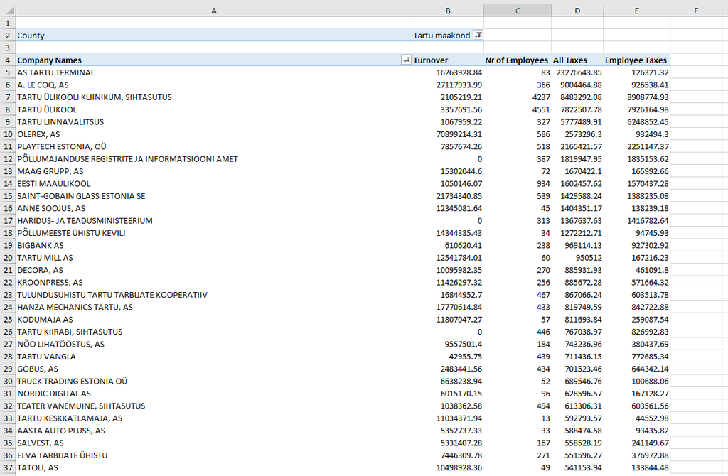

Tartu Pivotal Table

Tallinn:

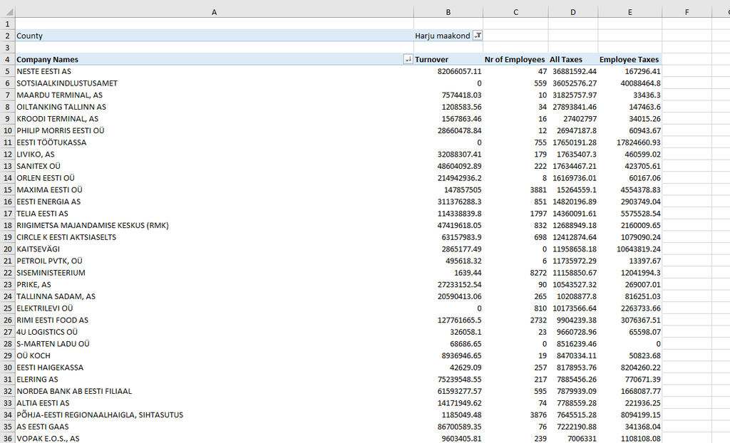

Tallinn Pivotal Table

PArnu:

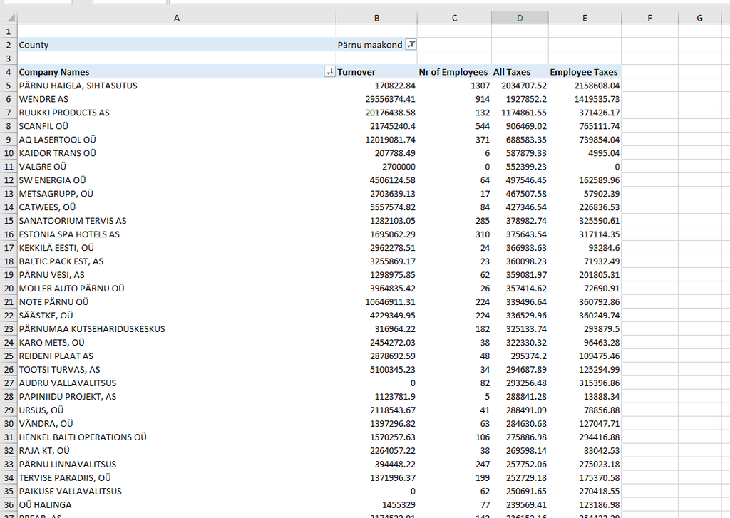

Parnu Pivotal Table

## Exercise 3

For the records with empty cells, I set 0.01 for these cells in order to avoid empty/null values. I also excluded the number of employees column in the clustering as it was causing errors.

```r
companies2 <- read.csv("C:/devstore/DM/hw11/companies_2.csv", header = TRUE, sep = ",")
companiesKmean <- kmeans(companies2[,4:6], centers = 5)

companiesKmean$cluster <- as.factor(companiesKmean$cluster)
```

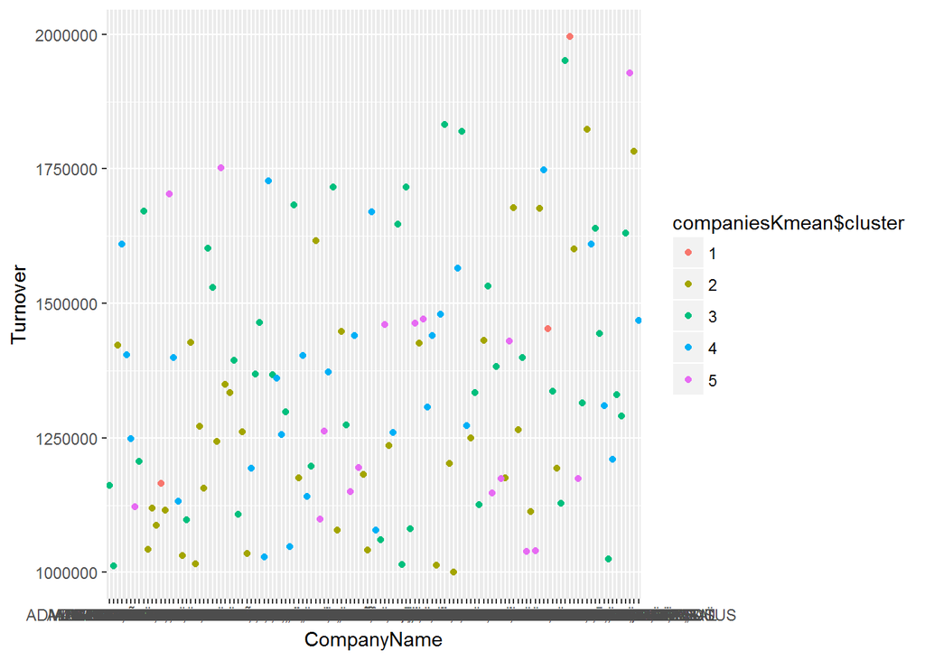

```r
ggplot(companies2, aes(CompanyName, Turnover, color = companiesKmean$cluster)) + geom_point()
```

This gives a wide distribution. So I plotted using company name vs EmployeeTax

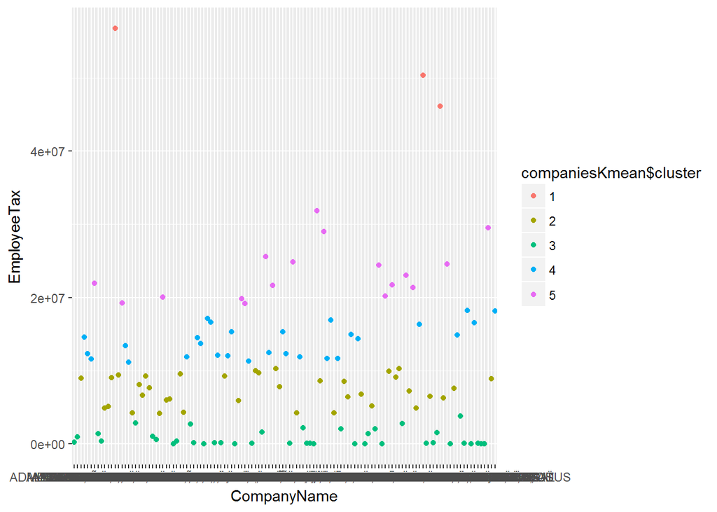

```r
ggplot(companies2, aes(CompanyName, EmployeeTax, color = companiesKmean$cluster)) + geom_point()
```

The above visualization gave a much better clustering than the initial plot

## Exercise 4

PCA stands for Principal Components Analysis. PCA is a linear transformation analysis. It finds directions of maximum variance of the data. It also finds directions that are mutually orthogonal and It is a statistical process which uses an orthogonal transformation in order to convert a set of correlated variables into a set of values of linearly uncorrelated variables called principal components.

Given a plot of a data set, PCA algorithm would first find the direction of the maximum variance, which is diagonal or at 45 degrees to the x-axis, and then it would find the direction of the mutually orthogonal line or the line perpendicular to the original line

## Exercise 5

For this exercise, I tried to solve it but I had some errors along the way. I have added my code for reference purpose because I couldnt figure out what i was doing wrong

```r
companyPca = prcomp(scale(companies2[4:6]))
companyScores = companyPca$x

# Using the first 2 PC
lmCompany = lm(formula = companies2$Employees ~ companyScores[,1:2])
```

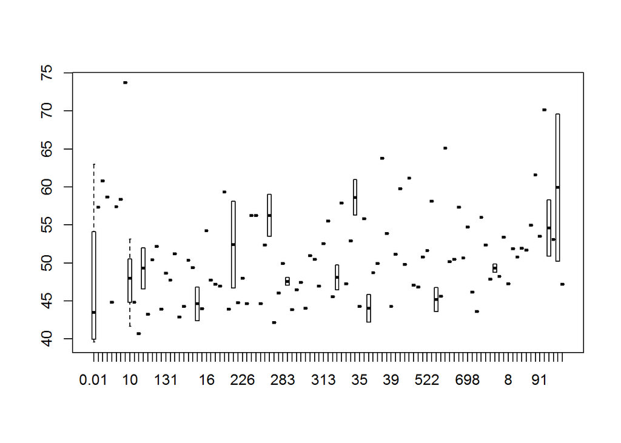

```r
plot(companies2$Employees, predict(lmCompany))
```

## Exercise 7

#### Project title : Recipes by Rating and Nutrition

#### Goals

1. Build a model to rate food by its nutritional benefits.
2. Build a model to generate new recipes from existing recipes
3. Predict meals for different category of people such as students, working class people, athletes, gym go-ers.

#### Source Data

https://www.kaggle.com/hugodarwood/epirecipes/version/1

#### Analysis methods

Both predictive and descriptive methods. Use descriptive methods to classify the eating habits of different people such as students, work-class and gym go-ers. Some possible task are:

- Exploratory analysis
- Linear classification
- Machine learning techniques such as linear regression, random forest, etc.

#### Expected results

1. Having rating for the nutritional benefits of food.
2. Visual representation demonstrating the nutritional facts associated to food.
3. Predict meals and analyse food consumption so as to know which food items have high requirements. This can be a beneficial information for upcoming and existing restaurants and supermarkets.

#### Estimated team size / required time

A team of four is required with estimated completion time of three weeks.

#### Project description URL:

https://docs.google.com/presentation/d/1JrCE0O0R3kRLt8jjrO4dO1LKySJ6WyOFeM9i23W37h4/edit#slide=id.g1d8ebd3a03_0_78